# Advance Bank Term Deposit

## Introduction

This notebook provides a detailed analysis of customer behavior and insights into factors influencing term deposit subscription.

## Load Dataset

```python
import pandas as pd
import numpy as np
import matplotlib.pyplot as plt
import seaborn as sns
# Load data
df = pd.read_csv("data.csv")
df.head()
```

|  | age | job | marital | education | default | housing | loan | contact | month | day_of_week | ... | campaign | pdays | previous | poutcome | emp.var.rate | cons.price.idx | cons.conf.idx | euribor3m | nr.employed | y |
| --- | --- | --- | --- | --- | --- | --- | --- | --- | --- | --- | --- | --- | --- | --- | --- | --- | --- | --- | --- | --- | --- |
| 0 | 56 | housemaid | married | basic.4y | no | no | no | telephone | may | mon | ... | 1 | 999 | 0 | nonexistent | 1.1 | 93.994 | -36.4 | 4.857 | 5191.0 | no |
| 1 | 57 | services | married | high.school | unknown | no | no | telephone | may | mon | ... | 1 | 999 | 0 | nonexistent | 1.1 | 93.994 | -36.4 | 4.857 | 5191.0 | no |
| 2 | 37 | services | married | high.school | no | yes | no | telephone | may | mon | ... | 1 | 999 | 0 | nonexistent | 1.1 | 93.994 | -36.4 | 4.857 | 5191.0 | no |
| 3 | 40 | admin. | married | basic.6y | no | no | no | telephone | may | mon | ... | 1 | 999 | 0 | nonexistent | 1.1 | 93.994 | -36.4 | 4.857 | 5191.0 | no |
| 4 | 56 | services | married | high.school | no | no | yes | telephone | may | mon | ... | 1 | 999 | 0 | nonexistent | 1.1 | 93.994 | -36.4 | 4.857 | 5191.0 | no |

5 rows × 21 columns

```python
print("Shape:", df.shape)
print("\nColumns:\n", df.columns.tolist())
```

```
Shape: (41188, 21)

Columns:
 ['age', 'job', 'marital', 'education', 'default', 'housing', 'loan', 'contact', 'month', 'day_of_week', 'duration', 'campaign', 'pdays', 'previous', 'poutcome', 'emp.var.rate', 'cons.price.idx', 'cons.conf.idx', 'euribor3m', 'nr.employed', 'y']
```

```python
df.info()
```

```
<class 'pandas.core.frame.DataFrame'>
RangeIndex: 41188 entries, 0 to 41187
Data columns (total 21 columns):
 #   Column          Non-Null Count  Dtype
---  ------          --------------  -----
 0   age             41188 non-null  int64
 1   job             41188 non-null  object
 2   marital         41188 non-null  object
 3   education       41188 non-null  object
 4   default         41188 non-null  object
 5   housing         41188 non-null  object
 6   loan            41188 non-null  object
 7   contact         41188 non-null  object
 8   month           41188 non-null  object
 9   day_of_week     41188 non-null  object
 10  duration        41188 non-null  int64
 11  campaign        41188 non-null  int64
 12  pdays           41188 non-null  int64
 13  previous        41188 non-null  int64
 14  poutcome        41188 non-null  object
 15  emp.var.rate    41188 non-null  float64
 16  cons.price.idx  41188 non-null  float64
 17  cons.conf.idx   41188 non-null  float64
 18  euribor3m       41188 non-null  float64
 19  nr.employed     41188 non-null  float64
 20  y               41188 non-null  object
dtypes: float64(5), int64(5), object(11)
memory usage: 6.6+ MB
```

```python
df.describe().T
```

|  | count | mean | std | min | 25% | 50% | 75% | max |
| --- | --- | --- | --- | --- | --- | --- | --- | --- |
| age | 41188.0 | 40.024060 | 10.421250 | 17.000 | 32.000 | 38.000 | 47.000 | 98.000 |
| duration | 41188.0 | 258.285010 | 259.279249 | 0.000 | 102.000 | 180.000 | 319.000 | 4918.000 |
| campaign | 41188.0 | 2.567593 | 2.770014 | 1.000 | 1.000 | 2.000 | 3.000 | 56.000 |
| pdays | 41188.0 | 962.475454 | 186.910907 | 0.000 | 999.000 | 999.000 | 999.000 | 999.000 |
| previous | 41188.0 | 0.172963 | 0.494901 | 0.000 | 0.000 | 0.000 | 0.000 | 7.000 |
| emp.var.rate | 41188.0 | 0.081886 | 1.570960 | -3.400 | -1.800 | 1.100 | 1.400 | 1.400 |
| cons.price.idx | 41188.0 | 93.575664 | 0.578840 | 92.201 | 93.075 | 93.749 | 93.994 | 94.767 |
| cons.conf.idx | 41188.0 | -40.502600 | 4.628198 | -50.800 | -42.700 | -41.800 | -36.400 | -26.900 |
| euribor3m | 41188.0 | 3.621291 | 1.734447 | 0.634 | 1.344 | 4.857 | 4.961 | 5.045 |
| nr.employed | 41188.0 | 5167.035911 | 72.251528 | 4963.600 | 5099.100 | 5191.000 | 5228.100 | 5228.100 |

```python
df.describe(include='object').T
```

|  | count | unique | top | freq |
| --- | --- | --- | --- | --- |
| job | 41188 | 12 | admin. | 10422 |
| marital | 41188 | 4 | married | 24928 |
| education | 41188 | 8 | university.degree | 12168 |
| default | 41188 | 3 | no | 32588 |
| housing | 41188 | 3 | yes | 21576 |
| loan | 41188 | 3 | no | 33950 |
| contact | 41188 | 2 | cellular | 26144 |
| month | 41188 | 10 | may | 13769 |
| day_of_week | 41188 | 5 | thu | 8623 |
| poutcome | 41188 | 3 | nonexistent | 35563 |
| y | 41188 | 2 | no | 36548 |

```python
df.isnull().sum()
```

```
age               0
job               0
marital           0
education         0
default           0
housing           0
loan              0
contact           0
month             0
day_of_week       0
duration          0
campaign          0
pdays             0
previous          0
poutcome          0
emp.var.rate      0
cons.price.idx    0
cons.conf.idx     0
euribor3m         0
nr.employed       0
y                 0
dtype: int64
```

```python
df.duplicated().sum()
```

```
12
```

```python
df = df.drop_duplicates()
```

```python
df['y'].value_counts()
```

```
y
no     36537
yes     4639
Name: count, dtype: int64
```

```python
df['y'].value_counts(normalize=True) * 100
```

```
y
no     88.733728
yes    11.266272
Name: proportion, dtype: float64
```

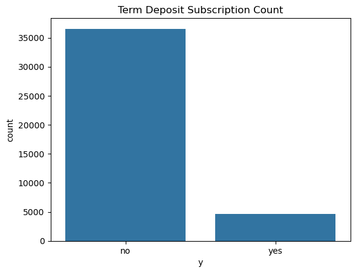

```python
sns.countplot(x='y', data=df)
plt.title("Term Deposit Subscription Count")
plt.show()
```

## Customer Demographics Analysis

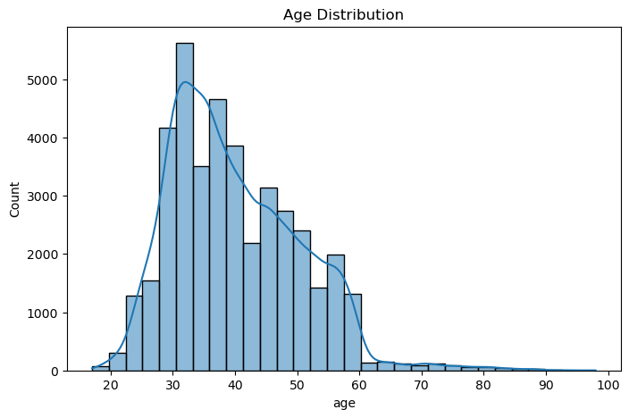

```python
# Age distribution

plt.figure(figsize=(8,5))
sns.histplot(df['age'], bins=30, kde=True)
plt.title("Age Distribution")
plt.show()
```

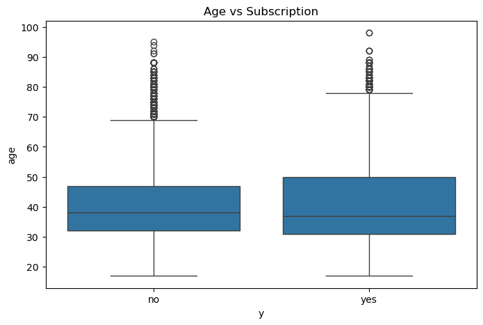

```python
#Age vs subscription

plt.figure(figsize=(8,5))
sns.boxplot(x='y', y='age', data=df)
plt.title("Age vs Subscription")
plt.show()
```

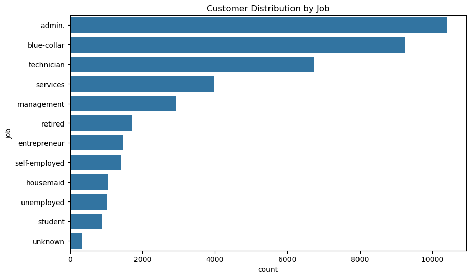

```python
# Job distribution

plt.figure(figsize=(10,6))
sns.countplot(y='job', data=df, order=df['job'].value_counts().index)
plt.title("Customer Distribution by Job")
plt.show()
```

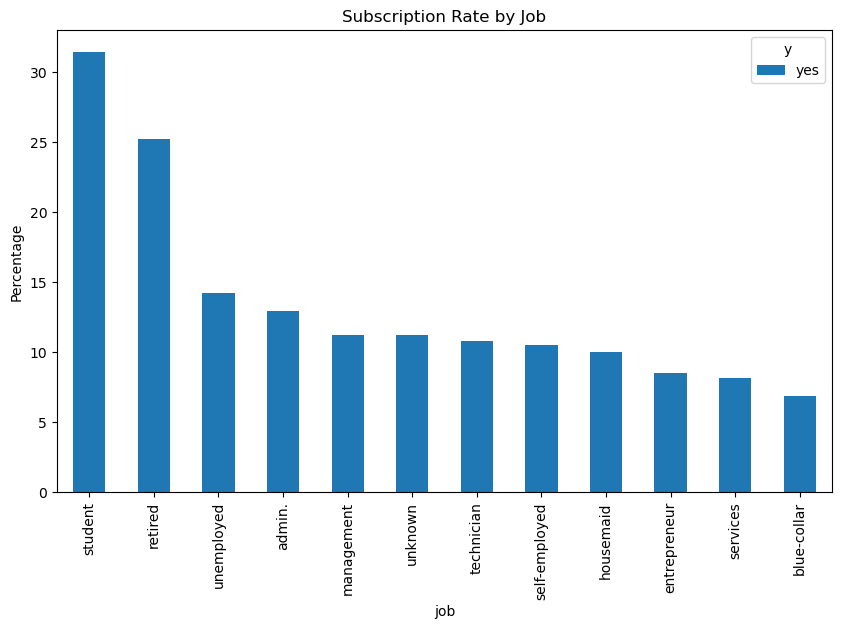

```python
#Job vs subscription

job_sub = pd.crosstab(df['job'], df['y'], normalize='index') * 100
job_sub.sort_values('yes', ascending=False)[['yes']].plot(kind='bar', figsize=(10,6))
plt.title("Subscription Rate by Job")
plt.ylabel("Percentage")
plt.show()
```

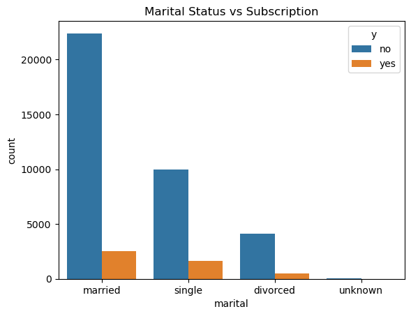

```python
#Marital status vs subscription

sns.countplot(x='marital', hue='y', data=df)
plt.title("Marital Status vs Subscription")
plt.show()
```

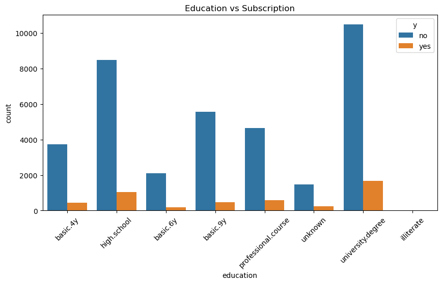

```python
#Education vs subscription

plt.figure(figsize=(10,5))
sns.countplot(x='education', hue='y', data=df)
plt.xticks(rotation=45)
plt.title("Education vs Subscription")
plt.show()
```

## Duration & Deposit Trends

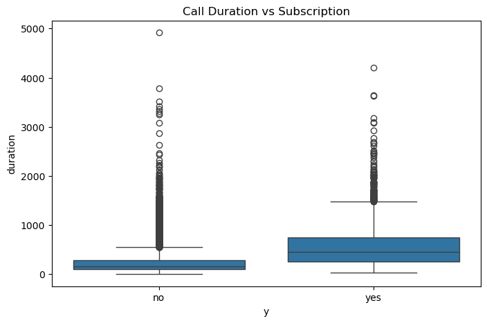

```python
#Duration vs subscription

plt.figure(figsize=(8,5))
sns.boxplot(x='y', y='duration', data=df)
plt.title("Call Duration vs Subscription")
plt.show()
```

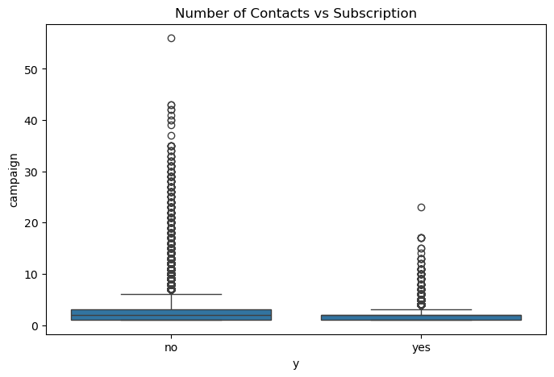

```python
#Campaign contacts vs subscription
plt.figure(figsize=(8,5))
sns.boxplot(x='y', y='campaign', data=df)
plt.title("Number of Contacts vs Subscription")
plt.show()
```

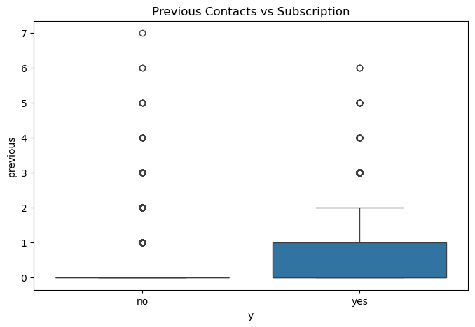

```python
#Previous contacts vs subscription
plt.figure(figsize=(8,5))
sns.boxplot(x='y', y='previous', data=df)
plt.title("Previous Contacts vs Subscription")
plt.show()
```

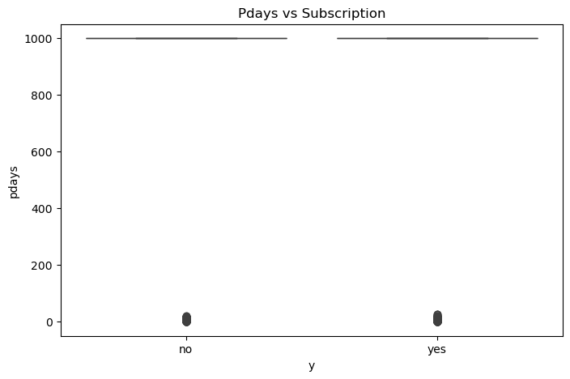

```python
#Pdays vs subscription
plt.figure(figsize=(8,5))
sns.boxplot(x='y', y='pdays', data=df)
plt.title("Pdays vs Subscription")
plt.show()
```

## Campaign Effectiveness

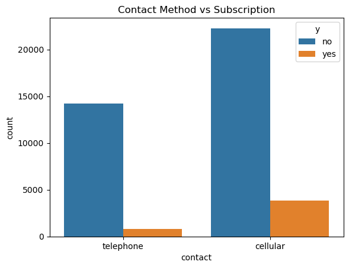

```python
# Contact method analysis
sns.countplot(x='contact', hue='y', data=df)
plt.title("Contact Method vs Subscription")
plt.show()
```

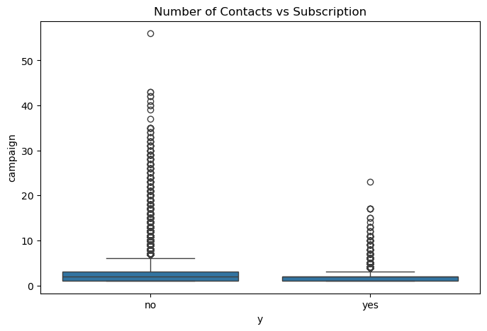

```python
# Number of contacts vs deposit subscription
plt.figure(figsize=(8,5))
sns.boxplot(x='y', y='campaign', data=df)
plt.title("Number of Contacts vs Subscription")
plt.show()
```

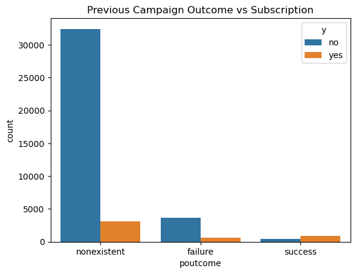

```python
#Previous campaign outcome
sns.countplot(x='poutcome', hue='y', data=df)
plt.title("Previous Campaign Outcome vs Subscription")
plt.show()
```

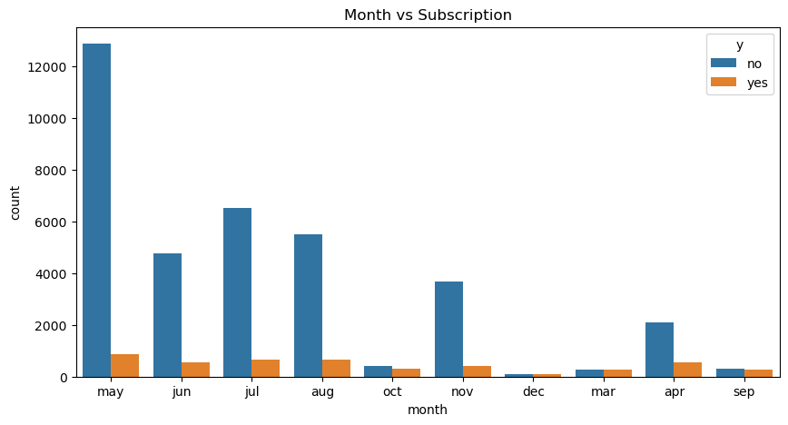

```python
#Month analysis
plt.figure(figsize=(10,5))
sns.countplot(x='month', hue='y', data=df)
plt.title("Month vs Subscription")
plt.show()
```

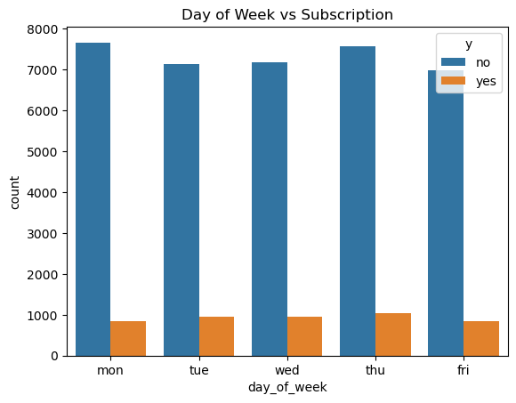

```python
#Day of week analysis
sns.countplot(x='day_of_week', hue='y', data=df)
plt.title("Day of Week vs Subscription")
plt.show()
```

## Correlation Heatmap

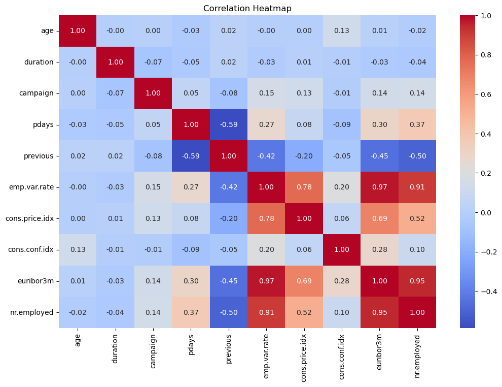

```python
# Correlation of numerical variables
plt.figure(figsize=(12,8))
numeric_df = df.select_dtypes(include=['int64', 'float64'])
sns.heatmap(numeric_df.corr(), annot=True, cmap='coolwarm', fmt='.2f')
plt.title("Correlation Heatmap")
plt.show()
```

## Predictive Modeling (Logistic Regression)

```python
# Encode categorical variables
df_model = df.copy()

# Encode target variable
df_model['y'] = df_model['y'].map({'no': 0, 'yes': 1})

# One-hot encode categorical features
df_model = pd.get_dummies(df_model, drop_first=True)

df_model.head()
```

|  | age | duration | campaign | pdays | previous | emp.var.rate | cons.price.idx | cons.conf.idx | euribor3m | nr.employed | ... | month_may | month_nov | month_oct | month_sep | day_of_week_mon | day_of_week_thu | day_of_week_tue | day_of_week_wed | poutcome_nonexistent | poutcome_success |
| --- | --- | --- | --- | --- | --- | --- | --- | --- | --- | --- | --- | --- | --- | --- | --- | --- | --- | --- | --- | --- | --- |
| 0 | 56 | 261 | 1 | 999 | 0 | 1.1 | 93.994 | -36.4 | 4.857 | 5191.0 | ... | True | False | False | False | True | False | False | False | True | False |
| 1 | 57 | 149 | 1 | 999 | 0 | 1.1 | 93.994 | -36.4 | 4.857 | 5191.0 | ... | True | False | False | False | True | False | False | False | True | False |
| 2 | 37 | 226 | 1 | 999 | 0 | 1.1 | 93.994 | -36.4 | 4.857 | 5191.0 | ... | True | False | False | False | True | False | False | False | True | False |
| 3 | 40 | 151 | 1 | 999 | 0 | 1.1 | 93.994 | -36.4 | 4.857 | 5191.0 | ... | True | False | False | False | True | False | False | False | True | False |
| 4 | 56 | 307 | 1 | 999 | 0 | 1.1 | 93.994 | -36.4 | 4.857 | 5191.0 | ... | True | False | False | False | True | False | False | False | True | False |

5 rows × 54 columns

```python
#predictons

from sklearn.model_selection import train_test_split
from sklearn.linear_model import LogisticRegression
from sklearn.metrics import accuracy_score, classification_report, confusion_matrix
from sklearn.preprocessing import StandardScaler

# Split features and target
X = df_model.drop('y', axis=1)
y = df_model['y']

# Train-test split
X_train, X_test, y_train, y_test = train_test_split(
    X, y, test_size=0.2, random_state=42, stratify=y
)

# Scale the data
scaler = StandardScaler()
X_train = scaler.fit_transform(X_train)
X_test = scaler.transform(X_test)

# Train model
model = LogisticRegression(max_iter=2000)
model.fit(X_train, y_train)

# Make predictions
y_pred = model.predict(X_test)

# Show results
print("Accuracy:", accuracy_score(y_test, y_pred))
print(classification_report(y_test, y_pred))
```

```
Accuracy: 0.9093006313744536
              precision    recall  f1-score   support

           0       0.93      0.97      0.95      7308
           1       0.65      0.42      0.51       928

    accuracy                           0.91      8236
   macro avg       0.79      0.70      0.73      8236
weighted avg       0.90      0.91      0.90      8236
```

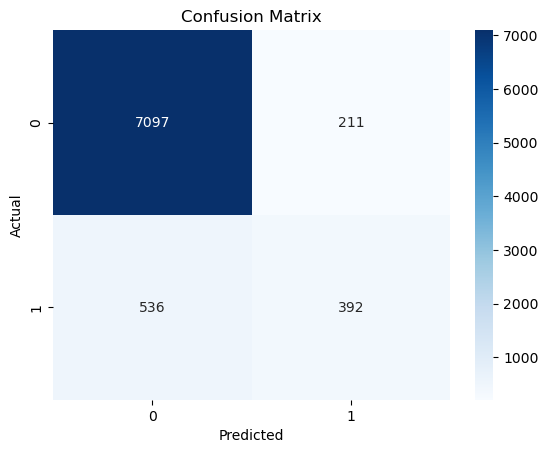

```python
#confusion matrix
cm = confusion_matrix(y_test, y_pred)
sns.heatmap(cm, annot=True, fmt='d', cmap='Blues')
plt.title("Confusion Matrix")
plt.xlabel("Predicted")
plt.ylabel("Actual")
plt.show()
```

```python
#

feature_importance = pd.DataFrame({
    'Feature': X.columns,
    'Coefficient': model.coef_[0]
})

feature_importance = feature_importance.sort_values(by='Coefficient', ascending=False)
feature_importance.head(10)
```

|  | Feature | Coefficient |
| --- | --- | --- |
| 1 | duration | 1.219853 |
| 6 | cons.price.idx | 1.191878 |
| 8 | euribor3m | 0.639884 |
| 9 | nr.employed | 0.293989 |
| 38 | month_aug | 0.286501 |
| 42 | month_mar | 0.223490 |
| 52 | poutcome_success | 0.166510 |
| 51 | poutcome_nonexistent | 0.129541 |
| 7 | cons.conf.idx | 0.087137 |
| 29 | education_university.degree | 0.066518 |

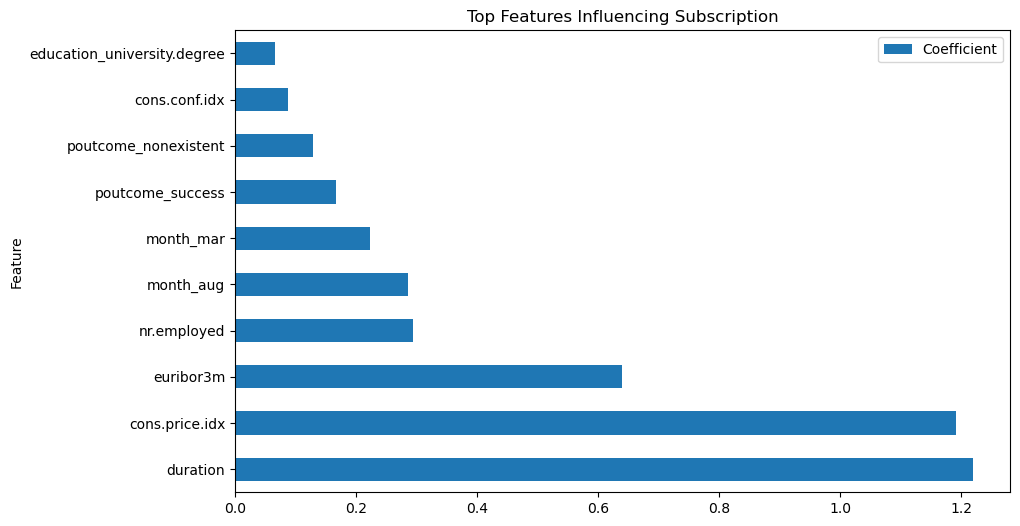

```python
feature_importance.head(10).plot(
    x='Feature', y='Coefficient', kind='barh', figsize=(10,6)
)
plt.title("Top Features Influencing Subscription")
plt.show()
```

## Final Conclusion

This project analyzes customer and campaign data to understand the factors influencing term deposit subscription. The analysis shows that call duration, previous campaign outcome, contact method, and number of contacts have a strong impact on whether a customer subscribes.

The logistic regression model provides a useful predictive approach for identifying potential customers and improving future campaign targeting.

### Recommendations

- Focus on customers with better previous campaign outcomes.
- Use cellular contact where possible.
- Avoid excessive repeated contact attempts.
- Use predictive analytics before launching campaigns.

## Key Takeaways

- Customers with longer call duration are more likely to subscribe.
- Previous campaign success strongly increases the chance of subscription.
- Cellular contact is more effective than telephone contact.
- Fewer contact attempts are generally associated with better outcomes.
- Customer demographics such as job, education, and age also influence subscription behavior.
- Logistic regression helps identify the strongest predictors of term deposit subscription.